# Factorial Designs & Interaction

Dylan Maddux

2024-11-06

**Some research has suggested that food cooked in iron pots tends to contain more iron than food cooked in other types of pots. One such experiment focused on Ethiopian cooking, using three types of pots (aluminum, clay, and iron) and three common Ethiopian dishes. The investigators cooked four samples of each dish using each of the three pots, for a total of 3 x 3 = 9 treatment combinations and N = 36 observations. The 36 dishes were cooked in a randomized order, and the iron content of each dish was measured in milligrams of iron per 100 grams of cooked food. The investigators expected that the meat dish would contain the most iron, followed by the legume dish and then the vegetable dish, but they were interested in determining whether the iron content was affected by the type of pot, and whether the effect of pot type on iron content would depend on which food was being cooked.**

```r
library(ggplot2)
library(dplyr)
```

**Question 1** Fit the two-way ANOVA model to the data and obtain the ANOVA table. Check the two standard diagnostic plots. Do the model conditions for inference appear to be met?

```r
Cooking <- read.csv("data/Cooking.csv")
mod1 <- aov(iron~type+food, Cooking)
anova(mod1)
```

```
## Analysis of Variance Table
##
## Response: iron
##           Df  Sum Sq Mean Sq F value    Pr(>F)
## type       2 24.8940 12.4470  61.413 1.649e-11 ***
## food       2  9.2969  4.6484  22.935 7.706e-07 ***
## Residuals 31  6.2829  0.2027
## ---
## Signif. codes:  0 '***' 0.001 '**' 0.01 '*' 0.05 '.' 0.1 ' ' 1
```

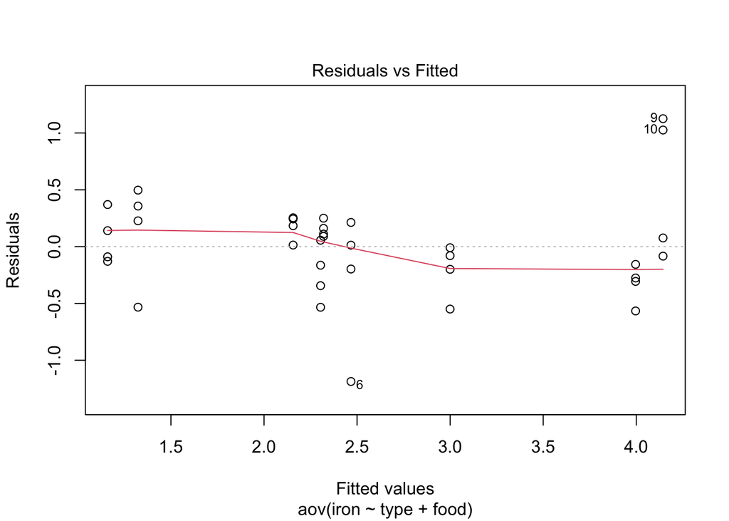

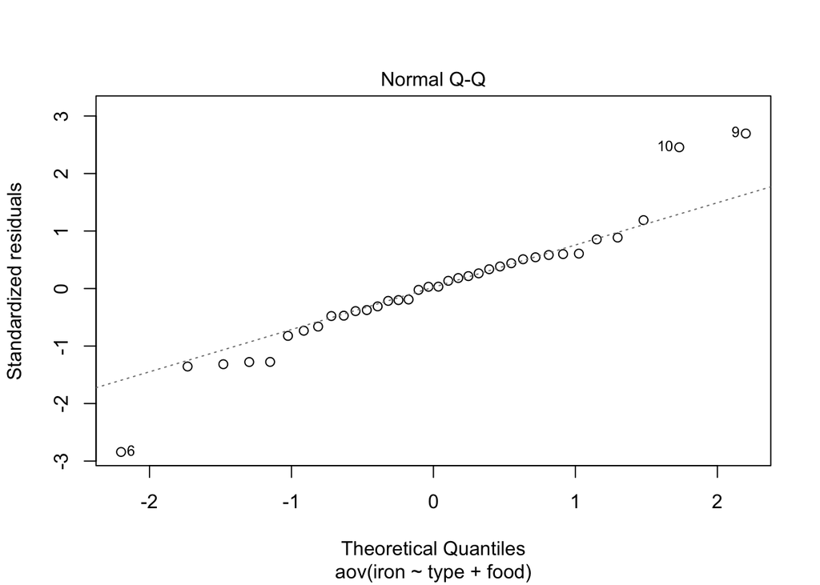

```r
plot(mod1, 1:2)
```

Although a few outliers exist in the plots, the conditions for inference appear to be met.

**Question 2** Does the ANOVA table indicate differences in mean iron among the types of pots, averaged across the three food types? Does it indicate differences in mean iron content among the three types of food, averaged across the three types of pots?

Yes, the ANOVA table indicates differences in mean iron content among the types of pots and types of food, as evidenced by the statistically significant p-values.

**Question 3** The main effects in the model cannot be directly interpreted if there is interaction between the two factors. Does the ANOVA table indicate discernible interaction?

```r
mod2 <- aov(iron~type*food, Cooking)
anova(mod2)
```

```
## Analysis of Variance Table
##
## Response: iron
##           Df  Sum Sq Mean Sq F value    Pr(>F)
## type       2 24.8940 12.4470  92.263 8.531e-13 ***
## food       2  9.2969  4.6484  34.456 3.699e-08 ***
## type:food  4  2.6404  0.6601   4.893  0.004247 **
## Residuals 27  3.6425  0.1349
## ---
## Signif. codes:  0 '***' 0.001 '**' 0.01 '*' 0.05 '.' 0.1 ' ' 1
```

```r
TukeyHSD(mod2, which = "type")
```

```
##   Tukey multiple comparisons of means
##     95% family-wise confidence level
##
## Fit: aov(formula = iron ~ type * food, data = Cooking)
##
## $type
##                    diff        lwr       upr     p adj
## Clay-Aluminum 0.1633333 -0.2084518 0.5351184 0.5287623
## Iron-Aluminum 1.8400000  1.4682149 2.2117851 0.0000000
## Iron-Clay     1.6766667  1.3048816 2.0484518 0.0000000
```

```r
TukeyHSD(mod2, which = "food")
```

```
##   Tukey multiple comparisons of means
##     95% family-wise confidence level
##
## Fit: aov(formula = iron ~ type * food, data = Cooking)
##
## $food
##                          diff        lwr        upr     p adj
## meat-legumes        0.1475000 -0.2242851  0.5192851 0.5932558
## vegetables-legumes -0.9966667 -1.3684518 -0.6248816 0.0000012
## vegetables-meat    -1.1441667 -1.5159518 -0.7723816 0.0000001
```

Yes, both the p-value and F-value are statistically significant.

**Question 4** Obtain an interaction plot between pot type and food type and explain what it indicates about the questions of interest in this study. How does the effect of pot type depend on the type of food being cooked? For each type of food, what type(s) of pot appear to produce the greatest mean iron content?

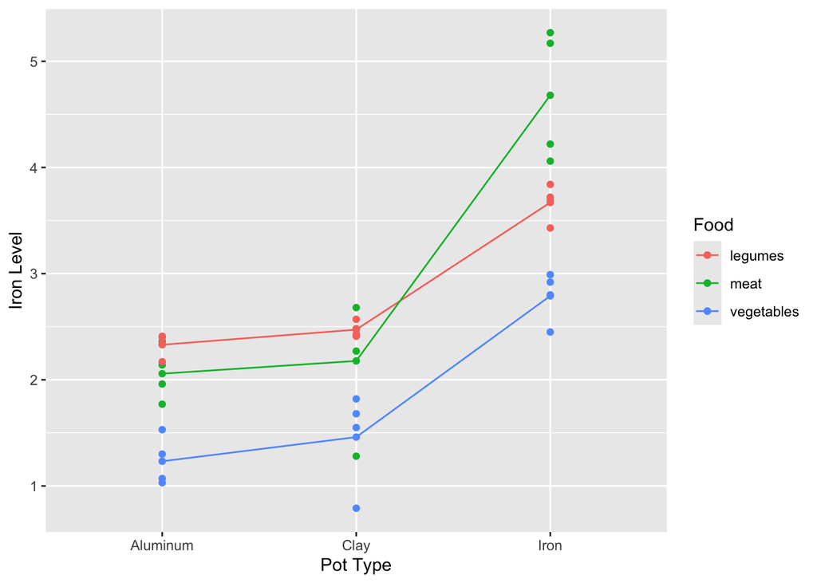

```r
ggplot(Cooking, aes(type, iron, color = food, group = food)) +
  stat_summary(fun = mean, geom = "point") +
  stat_summary(fun = mean, geom = "line") +
  geom_point() +
  labs( x = "Pot Type",
        y = "Iron Level",
        color = "Food")
```

The effect of pot type on iron content is greatest for meat, while it is similar for legumes and vegetables. For all three types of food, iron pots appear to produce the greatest mean iron content, followed by clay pots then aluminum pots.

**Question 5** Refit the model without the interaction and assess/interpret the main effects. Which types of pots differ discernibly from each other, and which lead to the greatest mean iron content? Which types of foods differ discernibly from each other, and which lead to the greatest mean iron content?

```r
TukeyHSD(mod1, which = "type")
```

```
##   Tukey multiple comparisons of means
##     95% family-wise confidence level
##
## Fit: aov(formula = iron ~ type + food, data = Cooking)
##
## $type
##                    diff        lwr      upr     p adj
## Clay-Aluminum 0.1633333 -0.2890114 0.615678 0.6513585
## Iron-Aluminum 1.8400000  1.3876553 2.292345 0.0000000
## Iron-Clay     1.6766667  1.2243220 2.129011 0.0000000
```

```r
Cooking %>%
  group_by(type) %>%
  summarise(mean(iron))
```

```
## # A tibble: 3 × 2
##   type     `mean(iron)`
##   <chr>           <dbl>
## 1 Aluminum         1.87
## 2 Clay             2.04
## 3 Iron             3.71
```

```r
TukeyHSD(mod1, which = "food")
```

```
##   Tukey multiple comparisons of means
##     95% family-wise confidence level
##
## Fit: aov(formula = iron ~ type + food, data = Cooking)
##
## $food
##                          diff        lwr        upr     p adj
## meat-legumes        0.1475000 -0.3048447  0.5998447 0.7042640
## vegetables-legumes -0.9966667 -1.4490114 -0.5443220 0.0000187
## vegetables-meat    -1.1441667 -1.5965114 -0.6918220 0.0000019
```

```r
Cooking %>%
  group_by(food) %>%
  summarise(mean(iron))
```

```
## # A tibble: 3 × 2
##   food       `mean(iron)`
##   <chr>             <dbl>
## 1 legumes            2.82
## 2 meat               2.97
## 3 vegetables         1.83
```

Iron differs significantly from both clay and aluminum, with iron leading to the greatest mean iron content; vegetables differ significantly from both meat and legumes, with meat leading to the greatest mean iron content.

**Question 6** Can any causal conclusions be drawn from this study? Do you think the conclusions from this study can be generalized?

Yes, since the variables were manipulated experimentally and the dishes were randomly assigned. However, the generalizability of the conclusions from this study are limited due to the small sample size and singular cooking source for all the dishes.